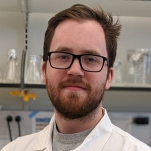

# Christopher Horn, PhD

## Bio

Bioinformatician with nearly a decade of experience in molecular biology & computational analysis. Currently working to advance public health initiatives at the [CDC](https://www.cdc.gov/) by developing novel tools/approaches to combat the spread of disease. Expertise in data analysis, pipeline development, and biological data interpretation.

Passionate about leveraging technology to solve complex biological challenges and improve health outcomes. Committed to continuous learning & innovation in the fields of bioinformatics & infectious diseases.

## Education

**University of Nebraska Medical Center** | Omaha, NE

- PhD in Immunology, Pathology, & Infectious Diseases | June 2019 - May 2023

**University of Nebraska at Omaha** | Omaha, NE

- MS in Biology | August 2017 - May 2019
- BS in Biotechnology | August 2012 - May 2017

## Experience

**Centers for Disease Control & Prevention** | Atlanta, GA

- APHL Fellow | August 2023 - Present

**University of Nebraska Medical Center** | Omaha, NE

- PhD Candidate | June 2019 - May 2023

**University of Nebraska at Omaha** | Omaha, NE

- MS Candidate | August 2017 - May 2019
- Undergraduate Research Assistant | August 2015 - August 2017